# Xing Ye

> **Tip**:The white wine dataset is used in the fellowing exploratory data analysis.

### get the column names of the DataFrame and summarize the data

```
##  [1] "X"                    "fixed.acidity"        "volatile.acidity"
##  [4] "citric.acid"          "residual.sugar"       "chlorides"
##  [7] "free.sulfur.dioxide"  "total.sulfur.dioxide" "density"
## [10] "pH"                   "sulphates"            "alcohol"
## [13] "quality"
```

```
## 'data.frame':    4898 obs. of  13 variables:
##  $ X                   : int  1 2 3 4 5 6 7 8 9 10 ...
##  $ fixed.acidity       : num  7 6.3 8.1 7.2 7.2 8.1 6.2 7 6.3 8.1 ...
##  $ volatile.acidity    : num  0.27 0.3 0.28 0.23 0.23 0.28 0.32 0.27 0.3 0.22 ...
##  $ citric.acid         : num  0.36 0.34 0.4 0.32 0.32 0.4 0.16 0.36 0.34 0.43 ...
##  $ residual.sugar      : num  20.7 1.6 6.9 8.5 8.5 6.9 7 20.7 1.6 1.5 ...
##  $ chlorides           : num  0.045 0.049 0.05 0.058 0.058 0.05 0.045 0.045 0.049 0.044 ...
##  $ free.sulfur.dioxide : num  45 14 30 47 47 30 30 45 14 28 ...
##  $ total.sulfur.dioxide: num  170 132 97 186 186 97 136 170 132 129 ...
##  $ density             : num  1.001 0.994 0.995 0.996 0.996 ...
##  $ pH                  : num  3 3.3 3.26 3.19 3.19 3.26 3.18 3 3.3 3.22 ...
##  $ sulphates           : num  0.45 0.49 0.44 0.4 0.4 0.44 0.47 0.45 0.49 0.45 ...
##  $ alcohol             : num  8.8 9.5 10.1 9.9 9.9 10.1 9.6 8.8 9.5 11 ...
##  $ quality             : int  6 6 6 6 6 6 6 6 6 6 ...
```

```
##        X        fixed.acidity    volatile.acidity  citric.acid
##  Min.   :   1   Min.   : 3.800   Min.   :0.0800   Min.   :0.0000
##  1st Qu.:1225   1st Qu.: 6.300   1st Qu.:0.2100   1st Qu.:0.2700
##  Median :2450   Median : 6.800   Median :0.2600   Median :0.3200
##  Mean   :2450   Mean   : 6.855   Mean   :0.2782   Mean   :0.3342
##  3rd Qu.:3674   3rd Qu.: 7.300   3rd Qu.:0.3200   3rd Qu.:0.3900
##  Max.   :4898   Max.   :14.200   Max.   :1.1000   Max.   :1.6600
##  residual.sugar     chlorides       free.sulfur.dioxide
##  Min.   : 0.600   Min.   :0.00900   Min.   :  2.00
##  1st Qu.: 1.700   1st Qu.:0.03600   1st Qu.: 23.00
##  Median : 5.200   Median :0.04300   Median : 34.00
##  Mean   : 6.391   Mean   :0.04577   Mean   : 35.31
##  3rd Qu.: 9.900   3rd Qu.:0.05000   3rd Qu.: 46.00
##  Max.   :65.800   Max.   :0.34600   Max.   :289.00
##  total.sulfur.dioxide    density             pH          sulphates
##  Min.   :  9.0        Min.   :0.9871   Min.   :2.720   Min.   :0.2200
##  1st Qu.:108.0        1st Qu.:0.9917   1st Qu.:3.090   1st Qu.:0.4100
##  Median :134.0        Median :0.9937   Median :3.180   Median :0.4700
##  Mean   :138.4        Mean   :0.9940   Mean   :3.188   Mean   :0.4898
##  3rd Qu.:167.0        3rd Qu.:0.9961   3rd Qu.:3.280   3rd Qu.:0.5500
##  Max.   :440.0        Max.   :1.0390   Max.   :3.820   Max.   :1.0800
##     alcohol         quality
##  Min.   : 8.00   Min.   :3.000
##  1st Qu.: 9.50   1st Qu.:5.000
##  Median :10.40   Median :6.000
##  Mean   :10.51   Mean   :5.878
##  3rd Qu.:11.40   3rd Qu.:6.000
##  Max.   :14.20   Max.   :9.000
```

# Unvariable Plot

### Examine every variable distribution using histograms

### Plot a histogram of the number of White Wine Quality

```
##
##    3    4    5    6    7    8    9
##   20  163 1457 2198  880  175    5
```

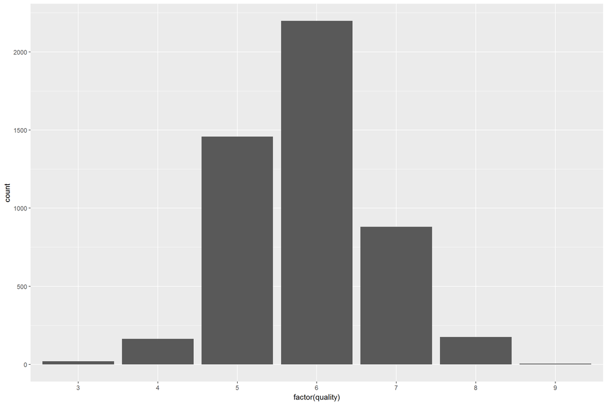

> The most quality of the white wine is 6.

From the table, we could find the datatype of quality of the white wine must be a discretable variance. So we transform the quality data type into factor.

```
##    Min. 1st Qu.  Median    Mean 3rd Qu.    Max.
##    8.00    9.50   10.40   10.51   11.40   14.20
```

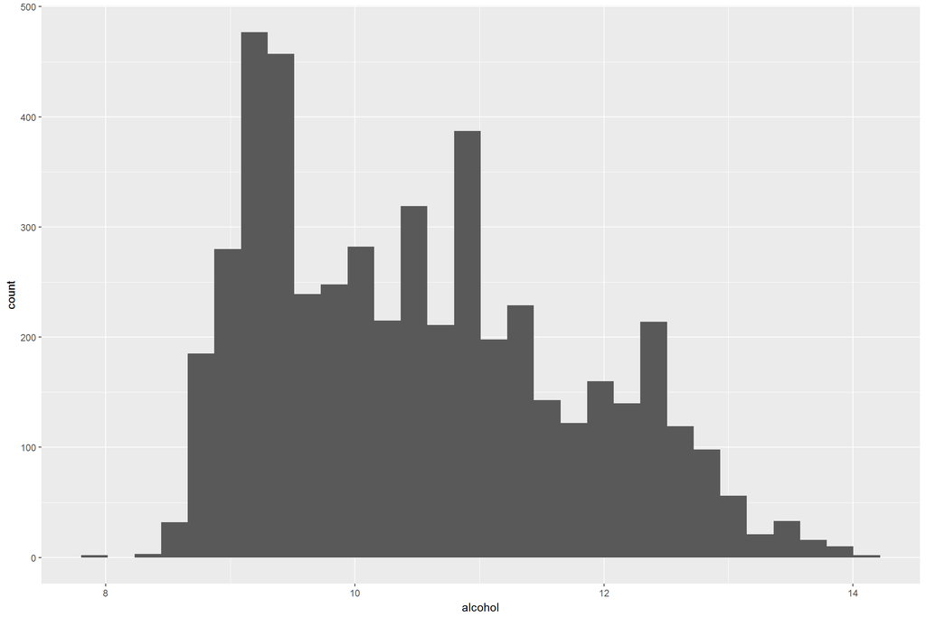

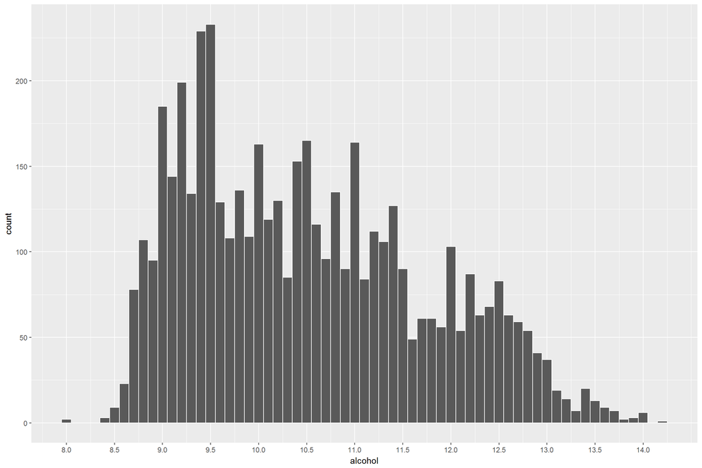

First, we simply describe the alcohol and plot the rough figure. According to the first graph, we change the axis and bin width to present the figure more precise in the second chart. From the later image, we know the least alcohol is 8.00 and the largest alcohol is 14.20. The majority of alcohol is about 9.5 and the trend of the peak shows an obvious fluctuation.

### Investigate free sulfur dioxide

```
##    Min. 1st Qu.  Median    Mean 3rd Qu.    Max.
##    2.00   23.00   34.00   35.31   46.00  289.00
```

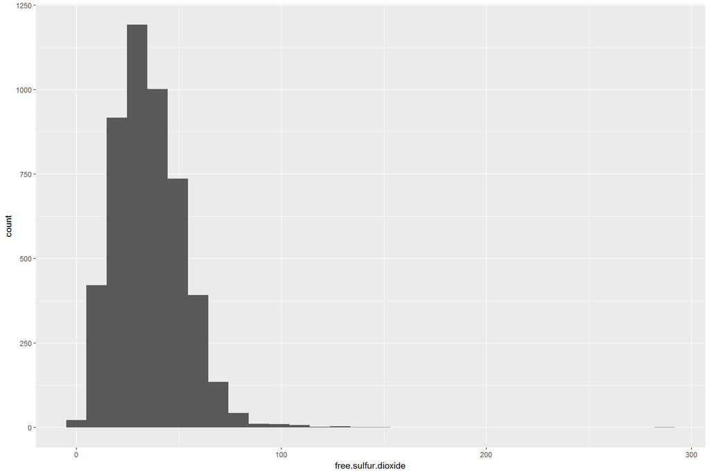

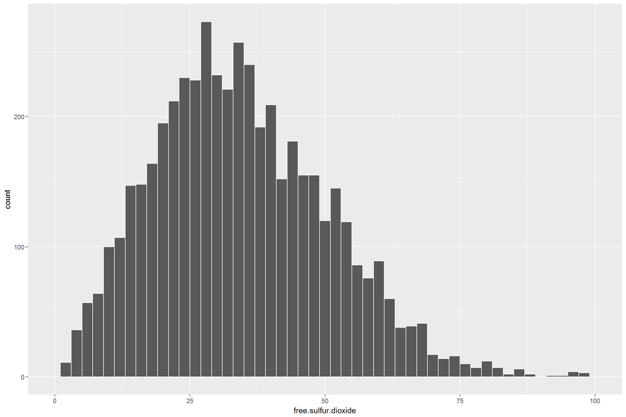

```
##    Min. 1st Qu.  Median    Mean 3rd Qu.    Max.
##   3.800   6.300   6.800   6.855   7.300  14.200
```

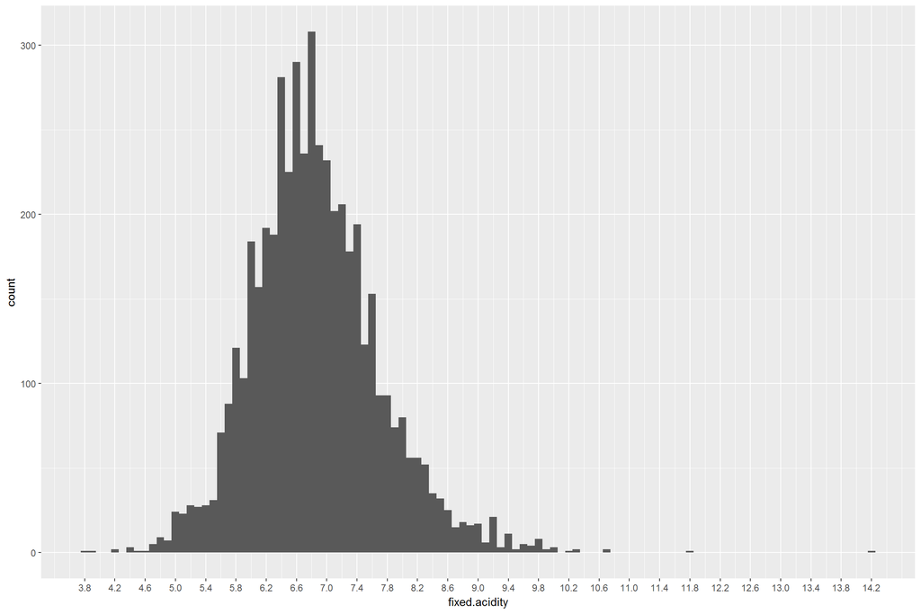

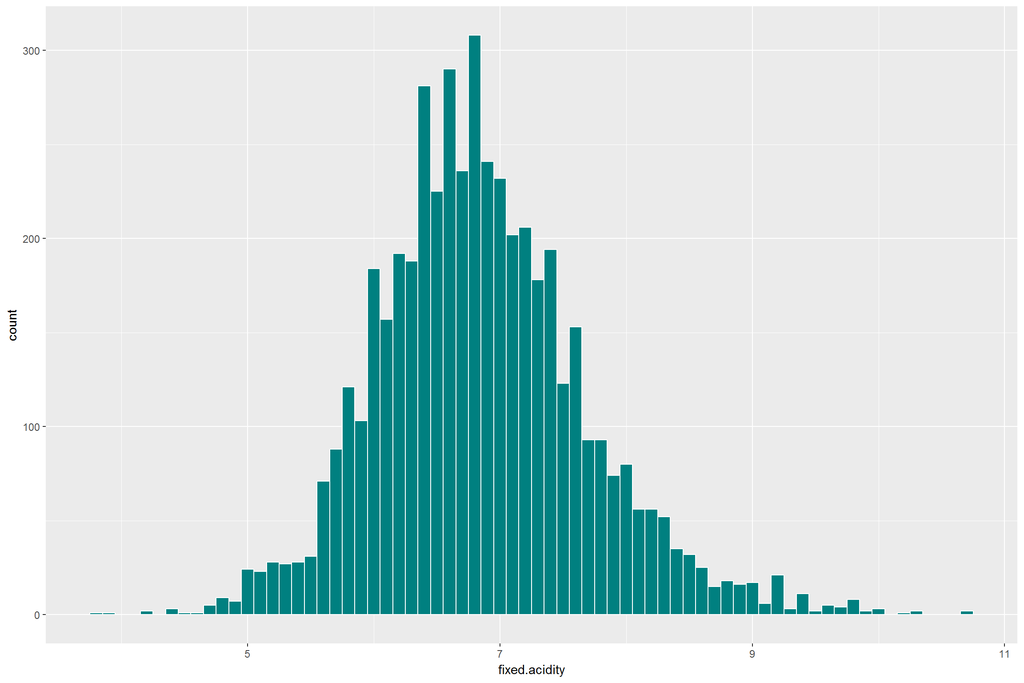

We truncate the range of x axis to better observe the figure. The The fixed acidity is centered between 6 and 9, showing an approximate normal distribution with its center near 6.8 and several peaks in the second plot.

```
##    Min. 1st Qu.  Median    Mean 3rd Qu.    Max.
##  0.0800  0.2100  0.2600  0.2782  0.3200  1.1000
```

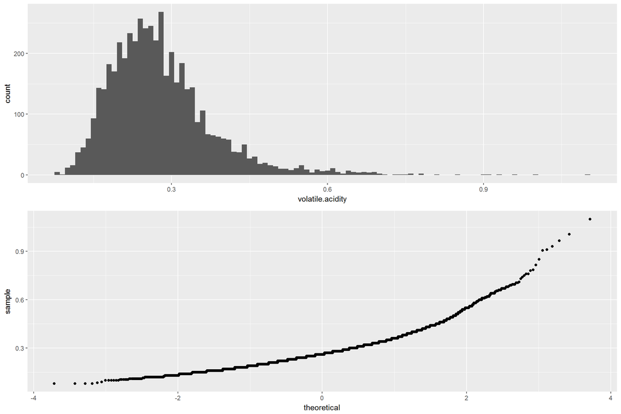

```
##    Min. 1st Qu.  Median    Mean 3rd Qu.    Max.
##  0.0000  0.2700  0.3200  0.3342  0.3900  1.6600
```

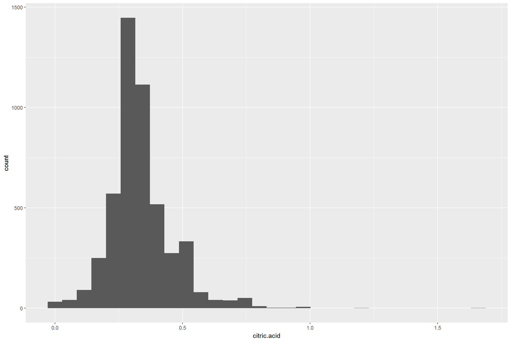

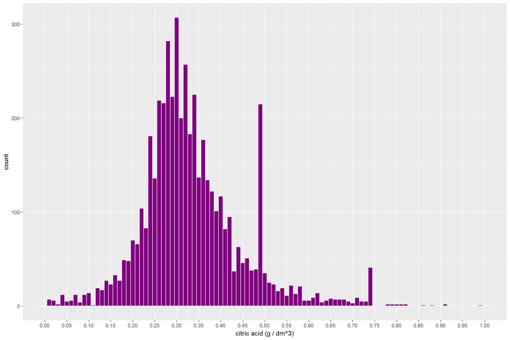

```
##    Min. 1st Qu.  Median    Mean 3rd Qu.    Max.
##  0.9871  0.9917  0.9937  0.9940  0.9961  1.0390
```

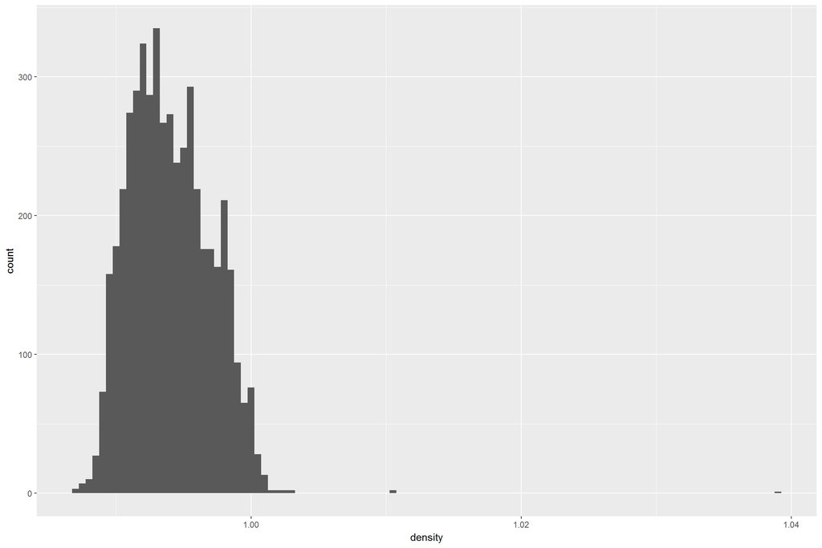

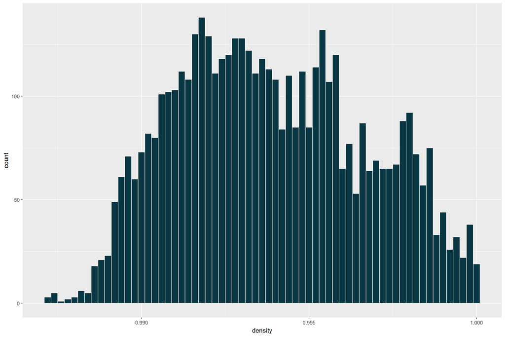

From the first graph, we could find the figure is affected by some anomalies. From the data description, we find out it’s rare the density greater than 1.0. So we limit the range and adjust the bn width to view the histogram more clearly.From the second graph, the main density data concentrates from 0.99 to 1.0 and has many small peaks .

```
##    Min. 1st Qu.  Median    Mean 3rd Qu.    Max.
##     9.0   108.0   134.0   138.4   167.0   440.0
```

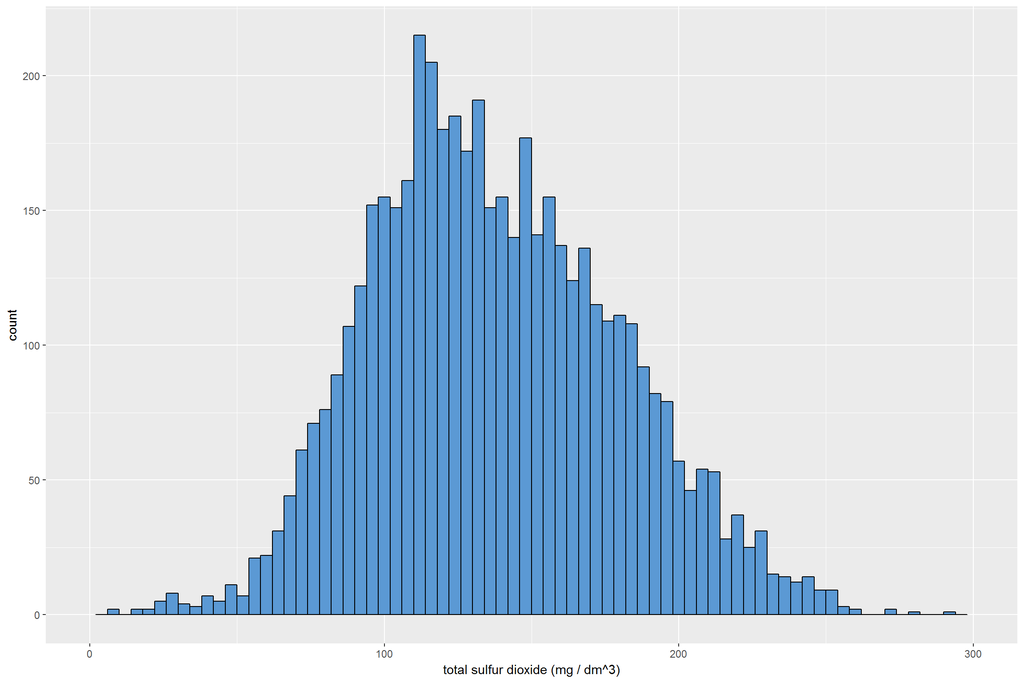

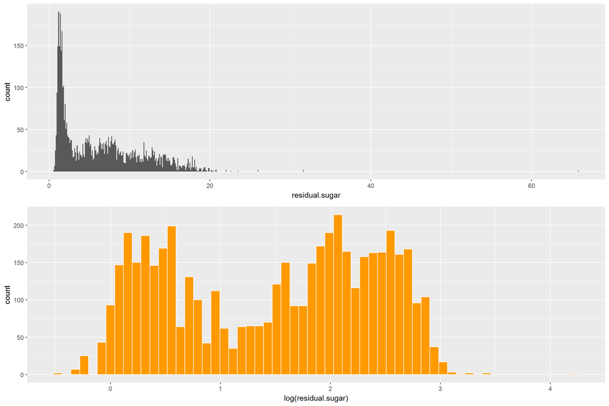

For the second graph, we adjust the axis,the binwidth, log-transformation, for the major data less than 20. The first image show there is a huge spike on the residual data that less 5. To avoid looking at this long tail data, we can tranform the variable by taking the natural log function. Two huge spikes and several small peaks are spotted in the second graph.

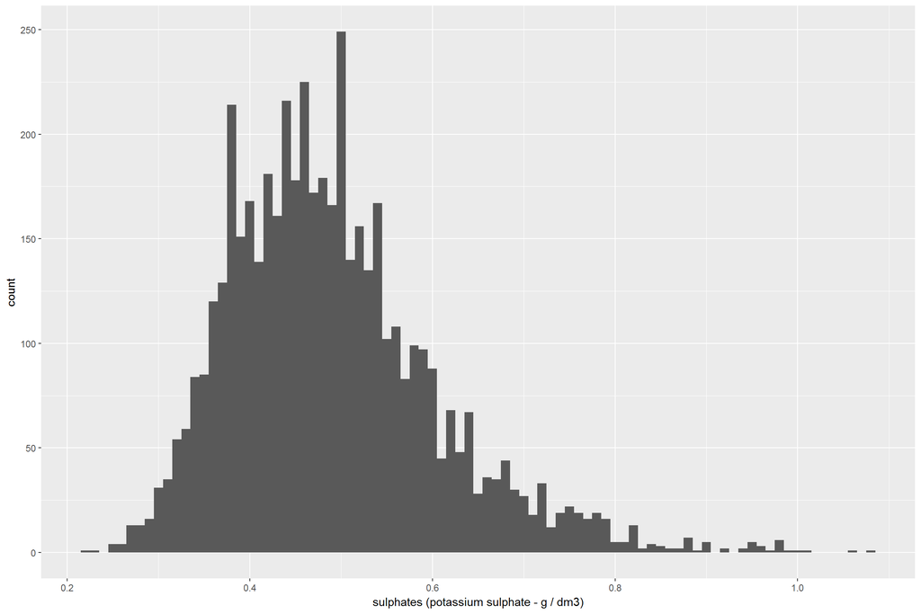

Setting the bin width properly, we can have a good sense of the distribution of sulphates nearly a normal distribution.

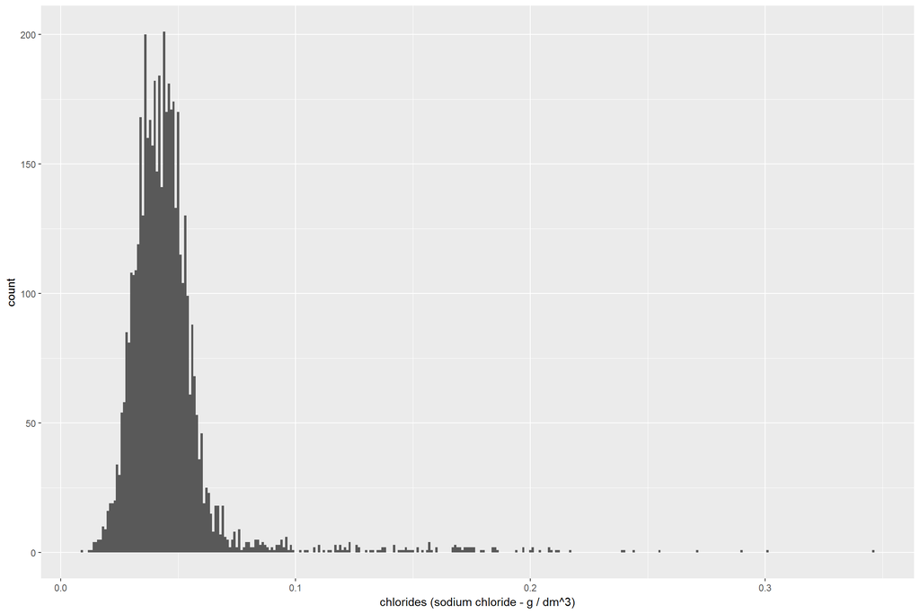

The most data concentrated under 0.1 with two apparent peaks. The graph seem has two peaks with a too long tail. The peaks rise and fall as the chlorides increasing.

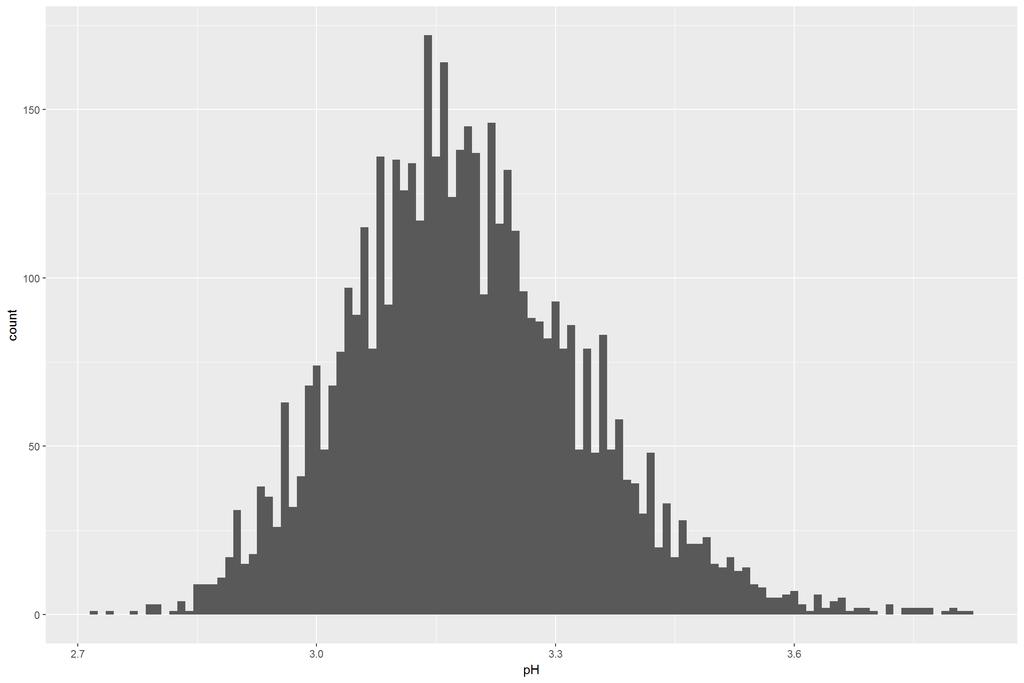

> The pH is centered around 3.15 with a closely normal distribution.

```
##    Min. 1st Qu.  Median    Mean 3rd Qu.    Max.
## 0.02362 0.19093 0.25368 0.25558 0.31579 0.71053
```

Creat a variable to observe the proportion of free sulfur dioxide in total sulfur dioxide and summarise the new variable.

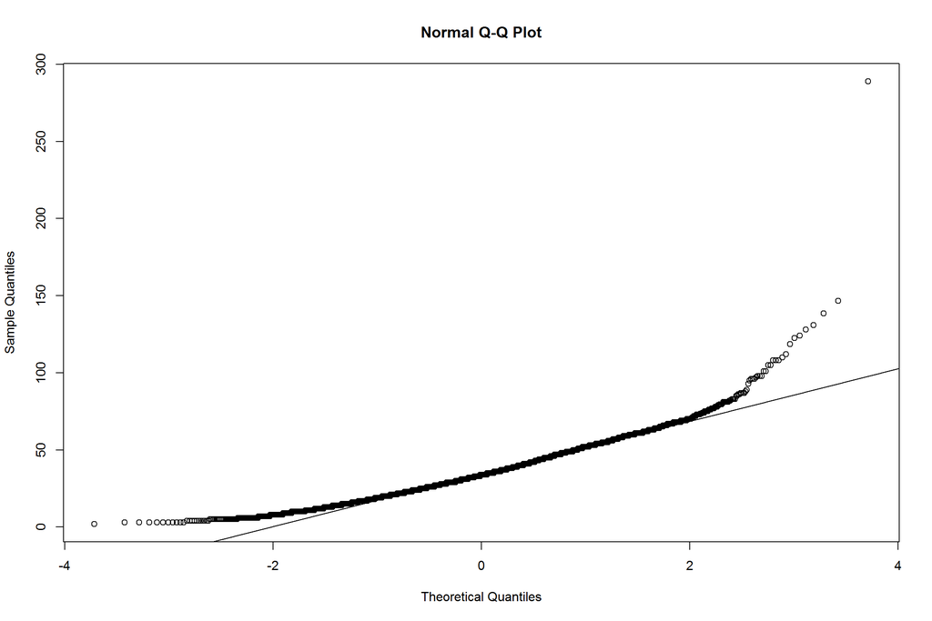

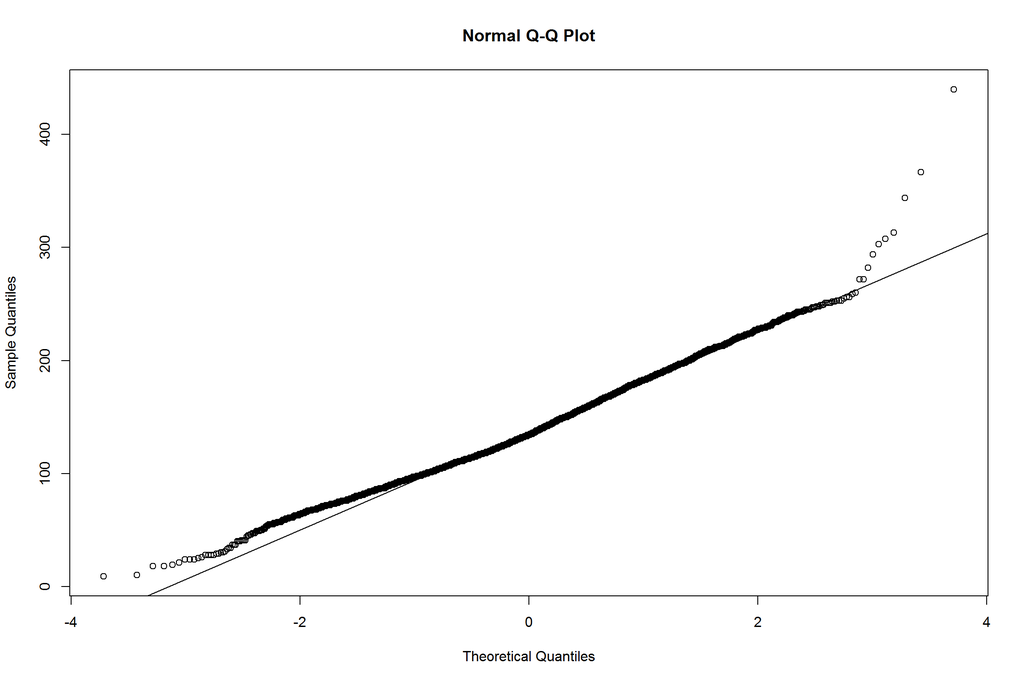

From the graph, we could found the curve of total sulfur dioxide basically conforms to the normal distribution.

# Univariate Analysis

**What is the structure of your dataset?**

There are 4898 white wines in the dataset with 13 features(X, fixed.acidity, volatile.acidity, citric.acid, residual.sugar, chlorides, density, sulphates, free.sulfur.dioxide, total.sulfur.dioxide, pH, alcohol and quality). The quality and X are int type and the rest are number. For have a good sense of quality, the variable could be ordered by factor variable with 7 levels.The most white wine are in quality 6 and the least in quality 9.

**What is/are the main feature(s) of interest in your dataset?**

The total sulfur dioxide, free sulfur dioxide are my aimed features. The reason I choose the two variables is the effect of the sulfur in white wine. Does the form of sulfur dioxide impact the quality?

**What other features in the dataset do you think will help support your investigation into your feature(s) of interest?**

The density, residual sugar and pH may contribute to my investigation because the sulfate are affected by pH in the wine. The residual might impact the density.

**Did you create any new variables from existing variables in the dataset?**

Yes, I creat a new variable called free sulfur dioxide rate.

**Of the features you investigated, were there any unusual distributions? Did you perform any operations on the data to tidy, adjust, or change the form of the data? If so, why did you do this?**

I change the data type of some variances to observe the distributions more convenient. Excepted the alcohol, the other features all has the outliers in a varying degrees. There are several unusual peaks in the distribution of citric acid.

# Bivariate Plot Section

> Plot the distributions in one graph.

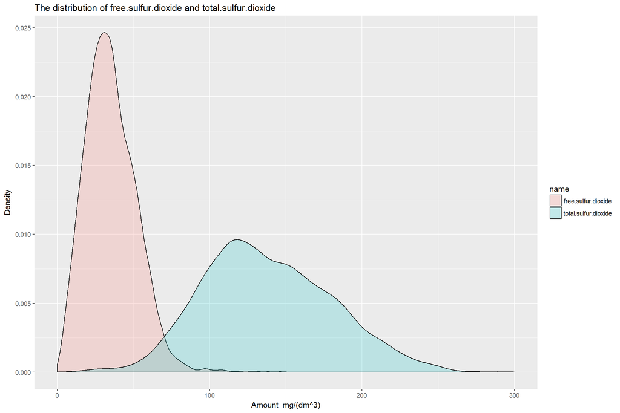

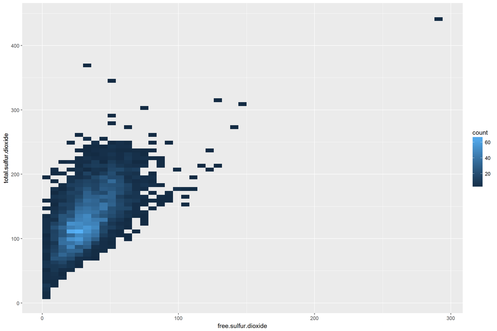

> Acquire the density plot of the most quality wine

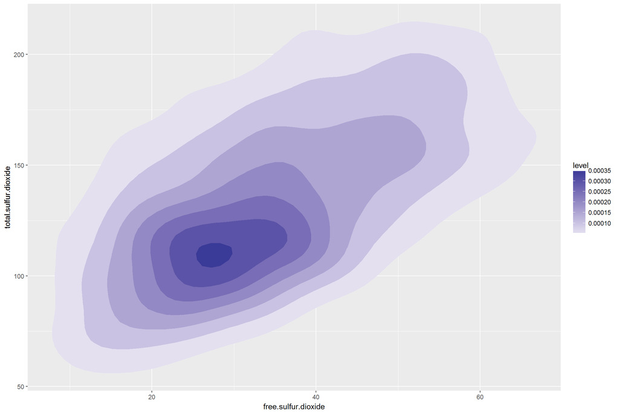

From the two graph, It spreads out from a region centered around (30, 120).

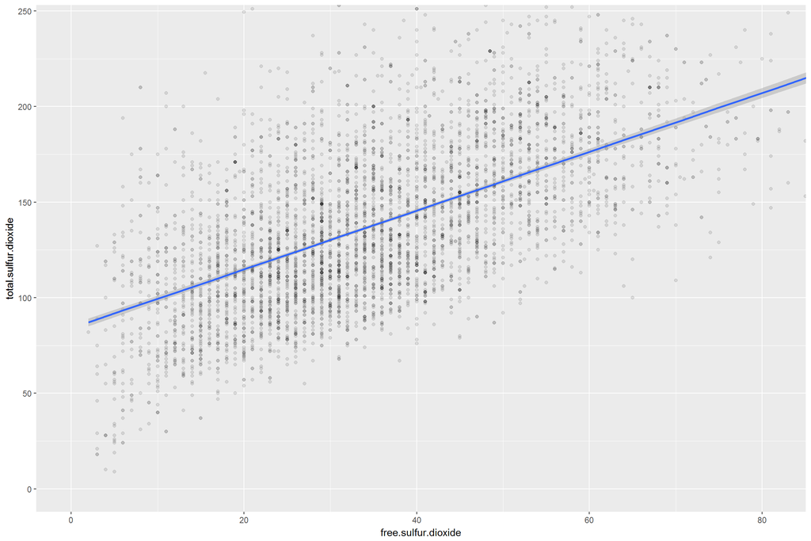

```
## df$quality: 3
##    Min. 1st Qu.  Median    Mean 3rd Qu.    Max.
##    5.00   13.25   33.50   53.33   47.50  289.00
## --------------------------------------------------------
## df$quality: 4
##    Min. 1st Qu.  Median    Mean 3rd Qu.    Max.
##    3.00    9.00   18.00   23.36   30.50  138.50
## --------------------------------------------------------
## df$quality: 5
##    Min. 1st Qu.  Median    Mean 3rd Qu.    Max.
##    2.00   22.00   35.00   36.43   50.00  131.00
## --------------------------------------------------------
## df$quality: 6
##    Min. 1st Qu.  Median    Mean 3rd Qu.    Max.
##    3.00   24.00   34.00   35.65   46.00  112.00
## --------------------------------------------------------
## df$quality: 7
##    Min. 1st Qu.  Median    Mean 3rd Qu.    Max.
##    5.00   25.00   33.00   34.13   41.00  108.00
## --------------------------------------------------------
## df$quality: 8
##    Min. 1st Qu.  Median    Mean 3rd Qu.    Max.
##    6.00   28.00   35.00   36.72   44.50  105.00
## --------------------------------------------------------
## df$quality: 9
##    Min. 1st Qu.  Median    Mean 3rd Qu.    Max.
##    24.0    27.0    28.0    33.4    31.0    57.0
```

We use the linear model to represent the tend with 99 percent data to present the the model of the most data. Then, We extract the most two quality subset data.

```
## # A tibble: 6 x 5
##   free.sulfur.dioxide quality mean_tsd median_tsd     n
##                 <dbl>  <fctr>    <dbl>      <dbl> <int>
## 1                   2      Q5 82.00000         82     1
## 2                   3      Q5 70.66667         64     3
## 3                   3      Q6 35.50000         32     4
## 4                   4      Q5 91.00000         91     2
## 5                   4      Q6 64.40000         28     5
## 6                   5      Q5 71.33333         61     9
```

```
##  free.sulfur.dioxide  quality         mean_tsd       median_tsd
##  Mode :logical       Mode :logical   Mode :logical   Mode :logical
##  FALSE:190           FALSE:190       FALSE:190       FALSE:190
##      n
##  Mode :logical
##  FALSE:190
```

```
##   free.sulfur.dioxide   Q5    Q6
## 1                   2 82.0    NA
## 2                   3 64.0  32.0
## 3                   4 91.0  28.0
## 4                   5 61.0 126.0
## 5                   6 86.5  60.5
## 6                   7 77.0 110.5
```

```
##  free.sulfur.dioxide     Q5              Q6
##  Mode :logical       Mode :logical   Mode :logical
##  FALSE:114           FALSE:92        FALSE:98
##                      TRUE :22        TRUE :16
```

Investigating the Correlation coefficient of each variable in the datafrme.

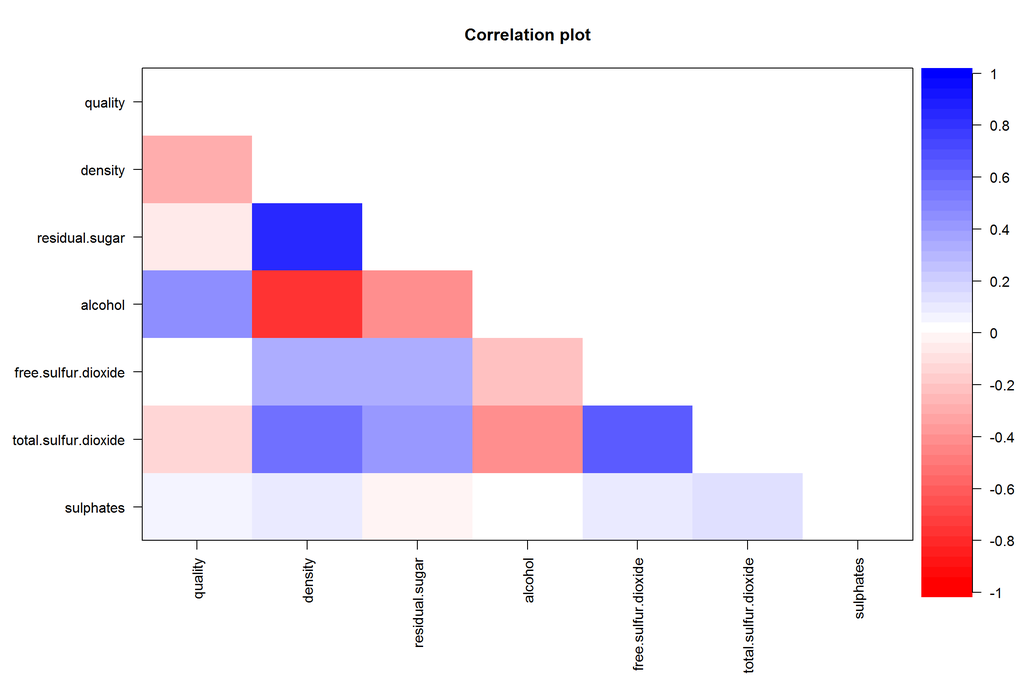

We could get the correlation coefficient matrix making a good sense of the relations in different variables. According to the results, we discovered the total sulfur dioxide have a strong relation with density and there are tree variables strongly related to each other.First, we exact the tree variables. Then, we plot the density and total sulfur dioxide by using scatter plot and suitable limitation and transparency.

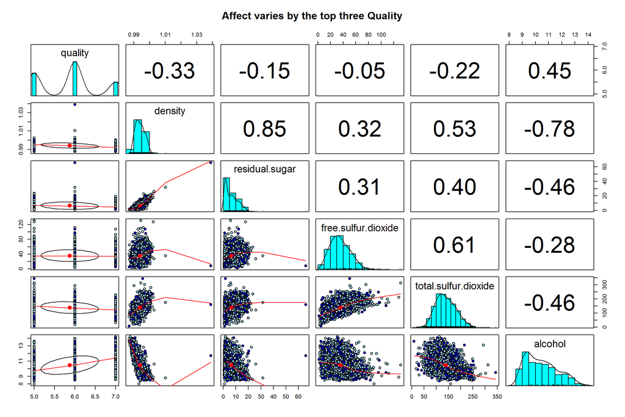

> Using the scattermatrix to plot the most count three quality with six interested features

```
## [1] -0.4506312
```

```
## [1] 0.8389665
```

```
## [1] -0.7801376
```

> Correlation Coefficient among residual.sugar vs alcohol, residual.sugar vs density and density vs alcohol.

According to the correlation coefficient results, The stongest correlation is between residual sugar and density, the weakest are residual sugar and alcohol.

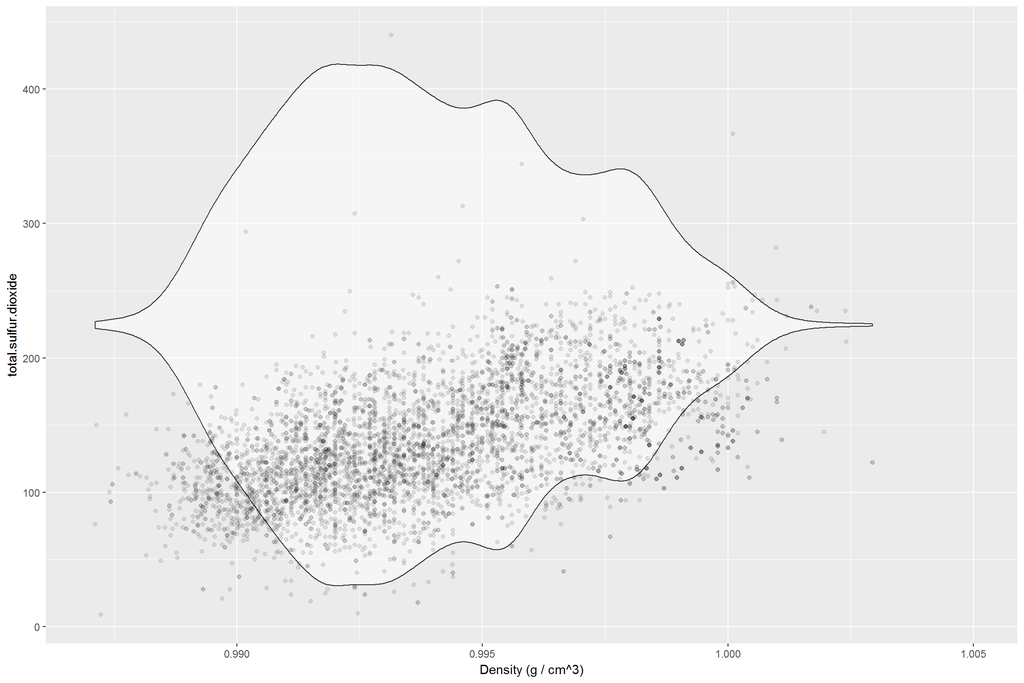

From the graph, we can discover the total sulfur dioxide increases as the density adding.

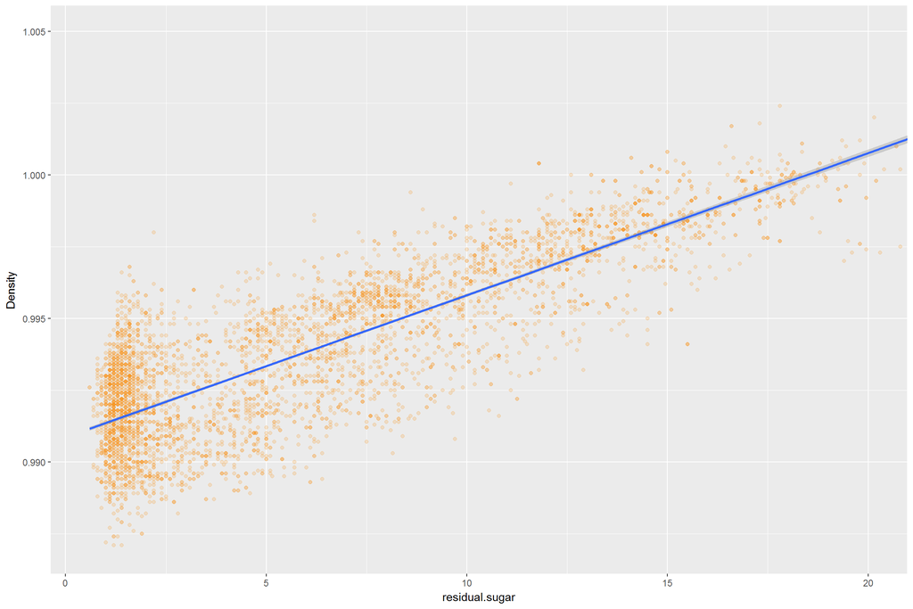

From the figure, we know that the density increase as the residual sugar adding. The points overplotted seriously with residual sugar less 20.

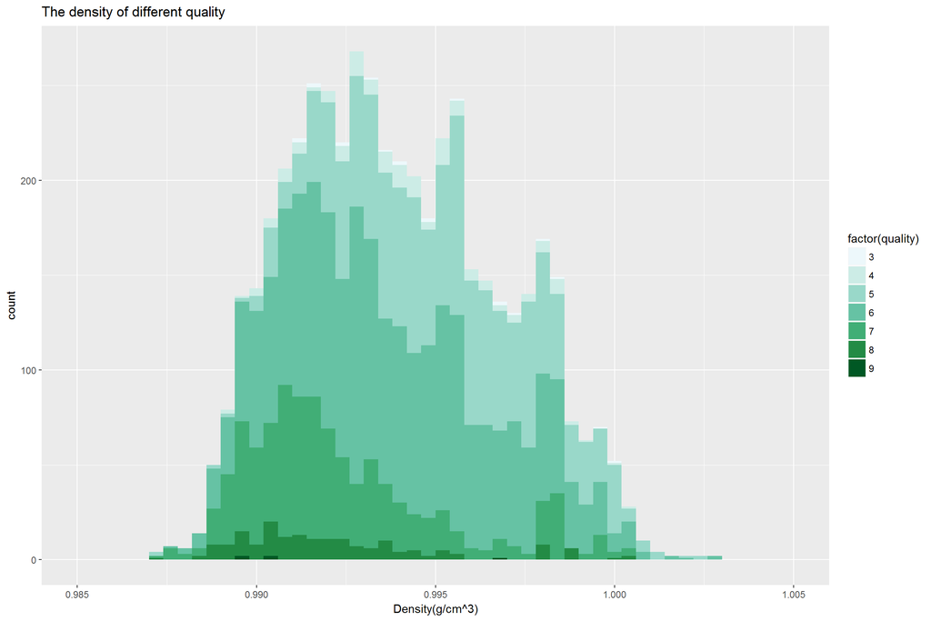

From the plots, The image show the count of the density vary with different quality

# Bivariate Analysis

**Talk about some of the relationships you observed in this part of the investigation. How did the feature(s) of interest vary with other features in the dataset?**

**Did you observe any interesting relationships between the other features (not the main feature(s) of interest)?**

Yes, I discover the residual sugar is intensely correlated with density. It could be residual sugar own a large relative molecular mass compared the other chemical components in the wine. The sugar belongs to carbohydrates which generally have a huge relative molecular mass in chemistry.

**What was the strongest relationship you found?**

The relationship between residual sugar and density because its correlation coefficient up to 0.84 which means a intense relation.

# Multivariate Plot Section

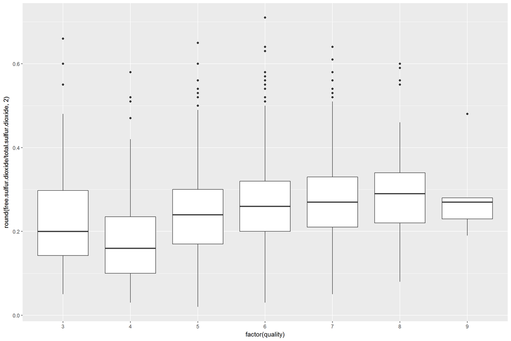

The image show the boxplot the free sulfur dioxide rate after rounding it to two decimals.Then, We extract the most two quality subset data.

```
## # A tibble: 6 x 5
##   free.sulfur.dioxide quality mean_tsd median_tsd     n
##                 <dbl>  <fctr>    <dbl>      <dbl> <int>
## 1                   2      Q5 82.00000         82     1
## 2                   3      Q5 70.66667         64     3
## 3                   3      Q6 35.50000         32     4
## 4                   4      Q5 91.00000         91     2
## 5                   4      Q6 64.40000         28     5
## 6                   5      Q5 71.33333         61     9
```

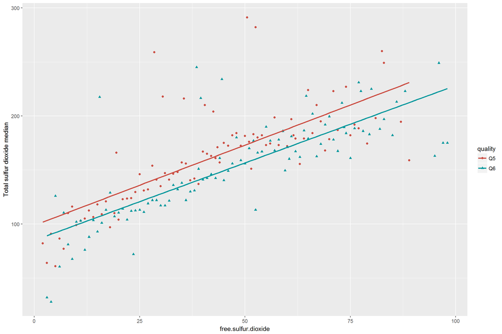

From the graph, the two linear regression lines are nearly parallel which means the similiar growth rate in the quality 5 and quality 6.

# Multivariate Analysis

** Talk about some of the relationships you observed in this part of the investigation. Were there features that strengthened each other in terms of looking at your feature(s) of interest?**

** Were there any interesting or surprising interactions between features?**

# Final Plots and Summary

## Plot one

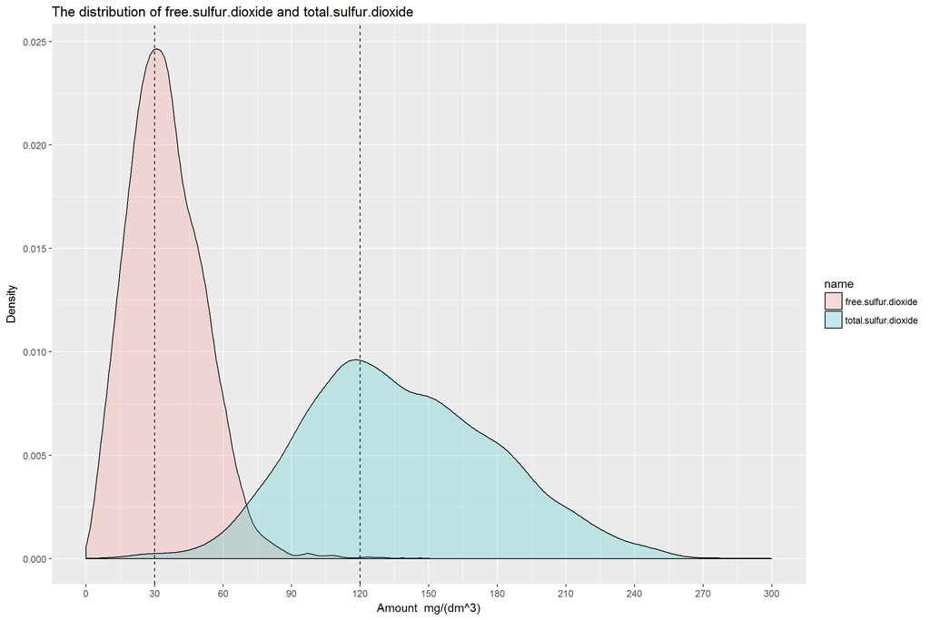

> Plot the two distributions into the same figure confirm the upper analysis about the distributions.

## Plot Two

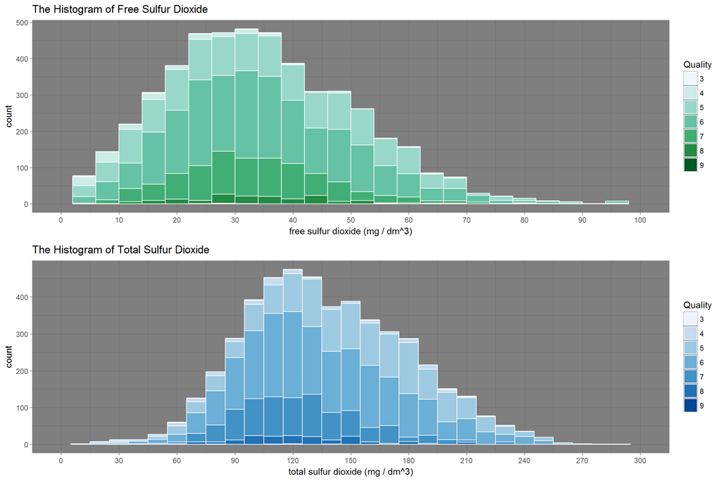